# ChIP-seq

Szymon Bzdzion

2023-05-03

# ChiP-seq analysis of public available data from GEO

GEO accesion number: GSE149324

### Title: Chromatin states in glioblastoma stem cells (HOXA-AS2 depletion)

**Summary**: Glioblastoma multiform account for about half of all gliomas and are the most deadly and aggressive forms. Its therapeutic resistance and tumor relapse rely on a subpopulation of cells, the so-called Glioma-stem Cells (GSCs). Here, we investigated for the role of the long non-coding RNA HOXA-AS2 in GSC biology by conducting descriptive and functional analyses of glioma samples classified according to their isocitrate dehydrogenase (IDH1) gene mutation status, and of glioma stem cells. We found that HOXA-AS2 is overexpressed only in aggressive (IDHwt) glioma and GSC. Sh-RNA-based depletion of HOXA-AS2 affects GSC both at the cellular and molecular levels with a decrease in proliferation and altered expression of several hundreds of their genes. Integrative analysis revealed that these changes is expression are not associated to changes in DNA methylation or chromatin signature at the promoter of most deregulated genes following HOXA-AS2 silencing in GSC, supporting a post-transcriptional regulation. In addition, transcription factor motif enrichment and correlation analyses sustained that HOXA-AS2 affect, directly or indirectly, expression of key transcription factors of GCS biology, including E2F8, E2F1, STAT1 and ATF3 to, in fine, contributes to their pathological status by promoting proliferation and modulating the inflammation pathway of Glioma Stem Cell.

## Get the data

I downloaded fastq files from SRA using `fasterq-dump` tool

```bash
fasterq-dump --split-files SRR18425899
fasterq-dump --split-files SRR18425900
fasterq-dump --split-files SRR18425901
fasterq-dump --split-files SRR18425902
```

## QC and trimming

Then I checked the quality of the sequences with `fastqc`

```bash
mkdir fastqc
fastqc *.fastq -o ./fastqc
```

Quality was overall good but there were adapters in all sequences so I performed trimming using `trimmomatic`

```bash
trimmomatic PE SRR18425899_1.fastq SRR18425899_2.fastq \
SRR18425899_1_trim.fq SRR18425899_un.fq \
SRR18425899_2_trim.fq SRR18425899_un.fq \
ILLUMINACLIP:truseq_adapters.fa:2:30:10 LEADING:3 TRAILING:3 SLIDINGWINDOW:4:15 MINLEN:95


trimmomatic PE SRR18425900_1.fastq SRR18425900_2.fastq \
SRR18425900_1_trim.fq SRR18425900_un.fq \
SRR18425900_2_trim.fq SRR18425900_un.fq \
ILLUMINACLIP:truseq_adapters.fa:2:30:10 LEADING:3 TRAILING:3 SLIDINGWINDOW:4:15 MINLEN:95

trimmomatic PE SRR18425901_1.fastq SRR18425901_2.fastq \
SRR18425901_1_trim.fq SRR18425901_un.fq \
SRR18425901_2_trim.fq SRR18425901_un.fq \
ILLUMINACLIP:truseq_adapters.fa:2:30:10 LEADING:3 TRAILING:3 SLIDINGWINDOW:4:15 MINLEN:95

trimmomatic PE SRR18425902_1.fastq SRR18425902_2.fastq \
SRR18425902_1_trim.fq SRR18425902_un.fq \
SRR18425902_2_trim.fq SRR18425902_un.fq \
ILLUMINACLIP:truseq_adapters.fa:2:30:10 LEADING:3 TRAILING:3 SLIDINGWINDOW:4:15 MINLEN:95
```

Then I examined the quality again

```bash
mkdir trim
mv *_[0-9]_trim.fq ./trim
cd ./trim
mkdir fastqc
fastqc *.fq
mkdir index
```

Adapter sequences were trimmed and quality was good

## Alignment

Next step was alignment using `bowtie2`. First I created the index, then I performed alignment for every file

```bash
bowtie2-build GRCh38.p13.genome.fa.gz ./index/HS_index
```

```bash
bowtie2 -p 4 -x ./index/HS_index -1 SRR18425899_1_trim.fq -2 SRR18425899_2_trim.fq \
-S SRR18425899.sam


bowtie2 -p 4 -x ./index/HS_index -1 SRR18425900_1_trim.fq -2 SRR18425900_2_trim.fq \
-S SRR18425900.sam


bowtie2 -p 4 -x ./index/HS_index -1 SRR18425901_1_trim.fq -2 SRR18425901_2_trim.fq \
-S SRR18425901.sam

bowtie2 -p 4 -x ./index/HS_index -1 SRR18425902_1_trim.fq -2 SRR18425902_2_trim.fq \
-S SRR18425902.sam
```

Then I used `samtools` to create bam files from sam files

```bash
samtools view -S -b SRR18425899.sam > SRR18425899.bam
samtools view -S -b SRR18425900.sam > SRR18425900.bam
samtools view -S -b SRR18425901.sam > SRR18425901.bam
samtools view -S -b SRR18425902.sam > SRR18425902.bam
```

I sorted the bam files and created indecies for every file and created bigWig files to visualize them in IGV

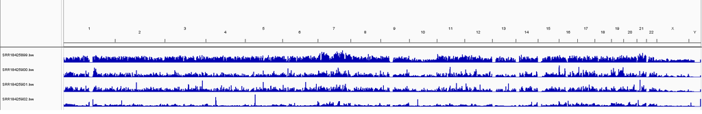

```bash
samtools sort -o SRR18425899_sorted.bam SRR18425899.bam
samtools sort -o SRR18425900_sorted.bam SRR18425900.bam
samtools sort -o SRR18425901_sorted.bam SRR18425901.bam
samtools sort -o SRR18425901_sorted.bam SRR18425901.bam

samtools index SRR18425899_sorted.bam
samtools index SRR18425900_sorted.bam
samtools index SRR18425901_sorted.bam
samtools index SRR18425902_sorted.bam

bamCoverage -b SRR18425899_sorted.bam --normalizeUsing RPKM --binSize 30 --smoothLength 300 -p 10 --extendReads 200 -o SRR18425899.bw
bamCoverage -b SRR18425900_sorted.bam --normalizeUsing RPKM --binSize 30 --smoothLength 300 -p 10 --extendReads 200 -o SRR18425900.bw
bamCoverage -b SRR18425901_sorted.bam --normalizeUsing RPKM --binSize 30 --smoothLength 300 -p 10 --extendReads 200 -o SRR18425901.bw
bamCoverage -b SRR18425902_sorted.bam --normalizeUsing RPKM --binSize 30 --smoothLength 300 -p 10 --extendReads 200 -o SRR18425902.bw
```

Visualization revealed issue with SRR18425899.bw file (chip antibody: H3K27me3) - there was a lot of background noise. That indicates some problems with library preparation or sequencing. Noisy background of the file resulted later in calling only 4 peaks.  
I decided to discard this file from further analysis.

## Peak calling

I used `macs2` for peak calling

```bash
macs2 callpeak -t ./bam/SRR18425900_sorted.bam \
-c ./bam/SRR18425902_sorted.bam \
-f BAM -g hs -n SRR18425899 \
--outdir peaks

macs2 callpeak -t ./bam/SRR18425899_sorted.bam \
-c ./bam/SRR18425902_sorted.bam \
-f BAM -g hs -n SRR18425899 \
--outdir peaks
```

Then I checked how many peaks are located in the blacklisted regions

```bash
gunzip ENCFF356LFX.bed.gz

bedtools intersect -a SRR18425900_peaks.narrowPeak -b ENCFF356LFX.bed -wa | wc -l
bedtools intersect -a SRR18425901_peaks.narrowPeak -b ENCFF356LFX.bed -wa | wc -l
```

and I removed them from the files

```bash
bedtools intersect -a SRR18425900_peaks.narrowPeak -b ENCFF356LFX.bed -v > SRR18425900_filtered.bed
bedtools intersect -a SRR18425901_peaks.narrowPeak -b ENCFF356LFX.bed -v > SRR18425901_filtered.bed
```

I also checked how many peaks overlap between two files

```bash
bedtools intersect -a SRR18425900_peaks.narrowPeak -b SRR18425901_peaks.narrowPeak -wa | wc -l
bedtools intersect -a SRR18425901_peaks.narrowPeak -b SRR18425900_peaks.narrowPeak -wa | wc -l
```

## Analysis in R

Loading the libraries

```r
library(ChIPseeker)
library(TxDb.Hsapiens.UCSC.hg38.knownGene)
library(clusterProfiler)
library(rtracklayer)
```

Loading the data and filtering so only regions mapped to the sequences on chromosomes are analyzed

```r
setwd("E:/Studia/Coding/Project/CHIP-seq/trimmed/trim/peaks")

H3K4me3_peaks <- readPeakFile('SRR18425900_peaks_filtered.bed')


H3K27ac_peaks <- readPeakFile('SRR18425901_peaks_filtered.bed')




H3K4me3_peaks_filter <-  H3K4me3_peaks[grep('^chr', seqnames(H3K4me3_peaks))]

H3K4me3_peaks_filter
```

```
## GRanges object with 55741 ranges and 7 metadata columns:
##           seqnames            ranges strand |                     V4        V5
##              <Rle>         <IRanges>  <Rle> |            <character> <integer>
##       [1]     chr1       28055-29311      * |  SRR18425900_peak_2980       131
##       [2]     chr1       29482-29814      * |  SRR18425900_peak_2981        34
##       [3]     chr1       96709-96933      * |  SRR18425900_peak_2982       108
##       [4]     chr1     198667-200113      * |  SRR18425900_peak_2983       501
##       [5]     chr1     273280-273589      * |  SRR18425900_peak_2984       112
##       ...      ...               ...    ... .                    ...       ...
##   [55737]     chrY 56953385-56955327      * | SRR18425900_peak_58741       229
##   [55738]     chrY 57067107-57067709      * | SRR18425900_peak_58742       312
##   [55739]     chrY 57067884-57068699      * | SRR18425900_peak_58743       216
##   [55740]     chrY 57145029-57145293      * | SRR18425900_peak_58744        80
##   [55741]     chrY 57172810-57172955      * | SRR18425900_peak_58745        31
##                    V6        V7        V8        V9       V10
##           <character> <numeric> <numeric> <numeric> <integer>
##       [1]           .   6.73812  15.45240  13.15590      1168
##       [2]           .   4.51288   5.40675   3.44605        79
##       [3]           .   8.69758  13.06420  10.83280       117
##       [4]           .  22.66740  53.93400  50.12660       538
##       [5]           .   8.68545  13.48860  11.24760       111
##       ...         ...       ...       ...       ...       ...
##   [55737]           .  14.49510  25.57920  22.95470       600
##   [55738]           .  17.53190  34.13770  31.21920       487
##   [55739]           .  12.07880  24.20930  21.63310        98
##   [55740]           .   7.59329  10.24000   8.09397       137
##   [55741]           .   4.83255   5.12536   3.16831        42
##   -------
##   seqinfo: 321 sequences from an unspecified genome; no seqlengths
```

```r
H3K27ac_peaks_filter <- H3K27ac_peaks[grep('^chr', seqnames(H3K27ac_peaks))]
H3K27ac_peaks_filter
```

```
## GRanges object with 68610 ranges and 7 metadata columns:
##           seqnames            ranges strand |                     V4        V5
##              <Rle>         <IRanges>  <Rle> |            <character> <integer>
##       [1]     chr1     778132-778601      * |  SRR18425902_peak_1933       121
##       [2]     chr1     817129-817344      * |  SRR18425902_peak_1934        40
##       [3]     chr1     817462-818362      * |  SRR18425902_peak_1935        38
##       [4]     chr1     826957-827219      * |  SRR18425902_peak_1936        99
##       [5]     chr1   1012708-1013353      * |  SRR18425902_peak_1937        64
##       ...      ...               ...    ... .                    ...       ...
##   [68606]     chrY 24039650-24039799      * | SRR18425902_peak_70566        52
##   [68607]     chrY 25630343-25630511      * | SRR18425902_peak_70567        64
##   [68608]     chrY 25630820-25630997      * | SRR18425902_peak_70568        40
##   [68609]     chrY 25643290-25643622      * | SRR18425902_peak_70569        40
##   [68610]     chrY 25821614-25821763      * | SRR18425902_peak_70570        40
##                    V6        V7        V8        V9       V10
##           <character> <numeric> <numeric> <numeric> <integer>
##       [1]           .   8.55402  14.87400  12.11240       359
##       [2]           .   4.99772   6.24693   4.07944       146
##       [3]           .   4.86736   5.94877   3.84239       708
##       [4]           .   7.83717  12.52290   9.93966       187
##       [5]           .   6.61527   8.81448   6.46873       371
##       ...         ...       ...       ...       ...       ...
##   [68606]           .   5.71640   7.49159   5.24611        42
##   [68607]           .   6.43507   8.78682   6.44153        89
##   [68608]           .   5.23728   6.24693   4.07944        50
##   [68609]           .   5.47684   6.24693   4.07944        83
##   [68610]           .   4.99772   6.24693   4.07944        80
##   -------
##   seqinfo: 235 sequences from an unspecified genome; no seqlengths
```

Coverage plot

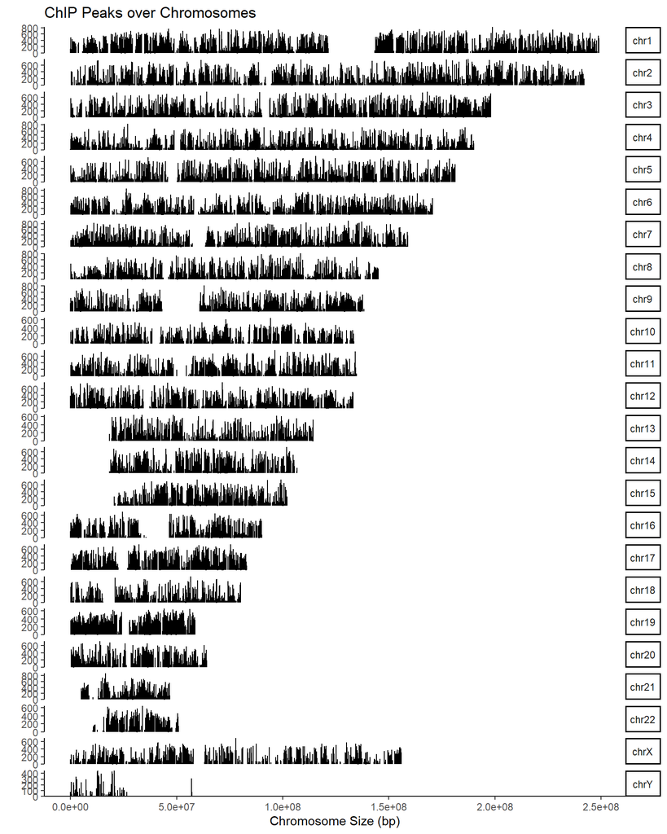

```r
covplot(H3K4me3_peaks_filter, weightCol = 'V5')
```

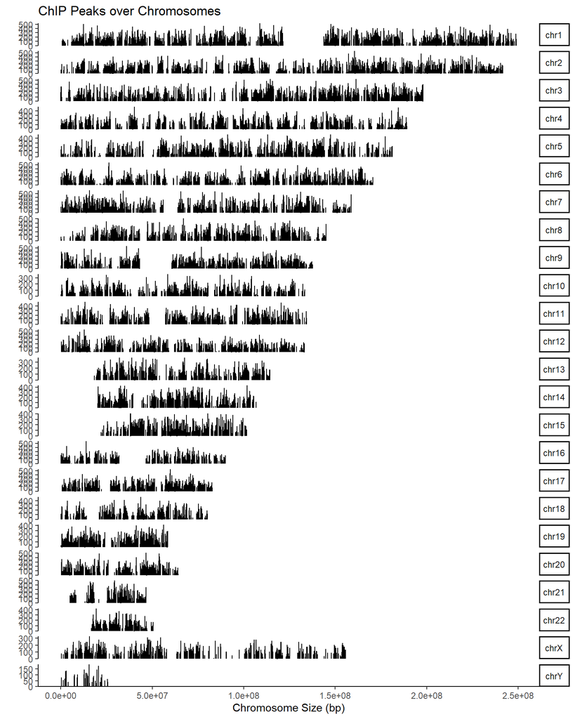

```r
covplot(H3K27ac_peaks_filter, weightCol = 'V5')
```

```r
promoter <- getPromoters(TxDb = TxDb.Hsapiens.UCSC.hg38.knownGene, upstream = 3000, downstream = 3000)
promoter
```

```
## GRanges object with 29748 ranges and 0 metadata columns:
##           seqnames              ranges strand
##              <Rle>           <IRanges>  <Rle>
##       [1]    chr19   58359751-58365751      -
##       [2]     chr8   18383311-18389311      +
##       [3]    chr20   44649252-44655252      -
##       [4]    chr18   28174946-28180946      -
##       [5]     chrX   49548278-49554278      +
##       ...      ...                 ...    ...
##   [29744]    chr15   34335060-34341060      -
##   [29745]     chr9 112330664-112336664      -
##   [29746]    chr21   34361006-34367006      +
##   [29747]    chr22   19119454-19125454      -
##   [29748]    chr22   50523461-50529461      -
##   -------
##   seqinfo: 640 sequences from an unspecified genome; no seqlengths
```

```r
tag_matrix <- getTagMatrix(H3K4me3_peaks_filter, windows = promoter)
```

```
## >> preparing start_site regions by gene... 2023-05-11 18:22:18
## >> preparing tag matrix...  2023-05-11 18:22:18
```

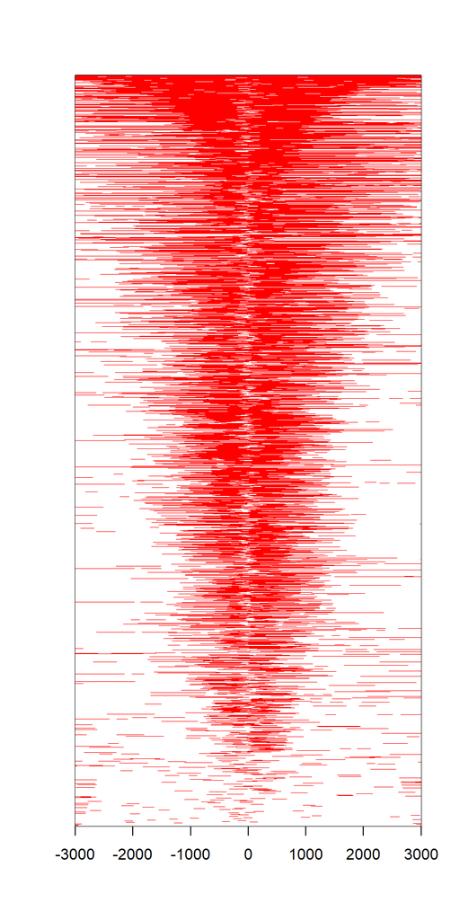

```r
tagHeatmap(tag_matrix, xlim = c(-3000, 3000))
```

```
## >> plotting figure...             2023-05-11 18:22:49
```

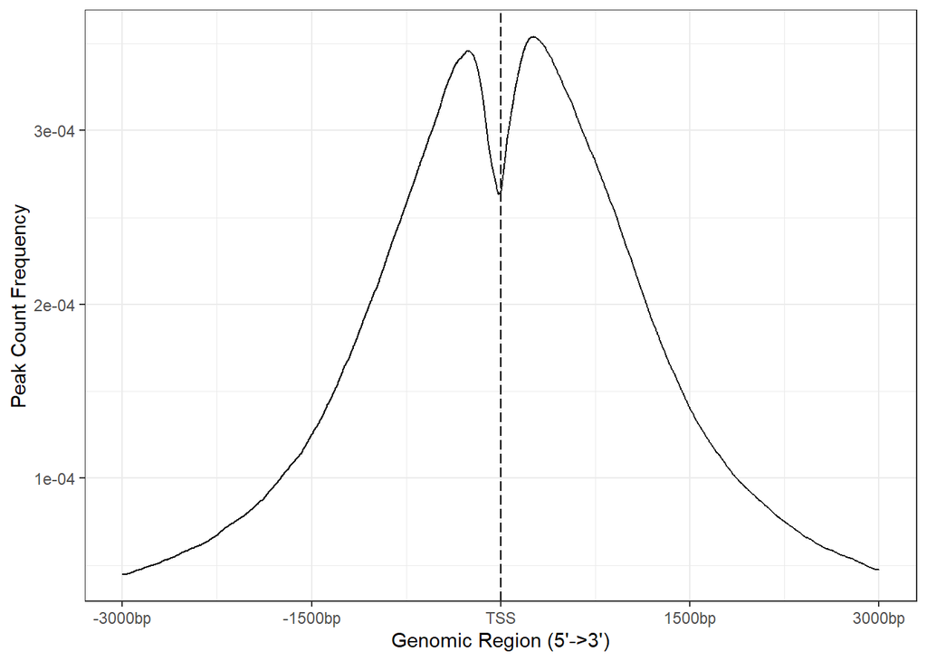

```r
plotAvgProf(tagMatrix = tag_matrix, xlim = c(-3000, 3000))
```

```
## #
## #.. 'TxDb' is a self-defined 'GRanges' object...
## #
```

```
## >> binning method is used...2023-05-11 18:22:49
## >> preparing body regions by gene... 2023-05-11 18:22:49
## >> preparing tag matrix by binning...  2023-05-11 18:22:49
## >> preparing matrix with extension from (TSS-20%)~(TTS+20%)... 2023-05-11 18:22:49
## >> 367 peaks(1.917551%), having lengths smaller than 800bp, are filtered... 2023-05-11 18:22:58
## >> Running bootstrapping for tag matrix...        2023-05-11 18:28:24
```

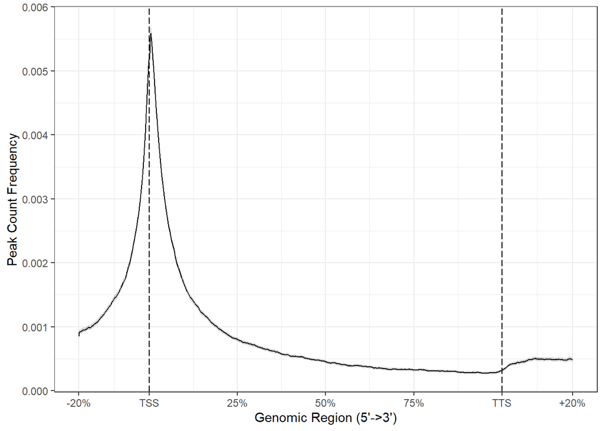

```r
plotPeakProf2(peak = H3K4me3_peaks, upstream = rel(0.2), downstream = rel(0.2),
              conf = 0.95, by = "gene", type = "body", nbin = 800,
              TxDb = TxDb.Hsapiens.UCSC.hg38.knownGene, weightCol = "V5",ignore_strand = F)
```

## Peak annotation

```r
peak_anno <- annotatePeak(H3K4me3_peaks_filter, tssRegion = c(-3000, 3000), TxDb = TxDb.Hsapiens.UCSC.hg38.knownGene,
                          annoDb = 'org.Hs.eg.db')
```

```
## >> preparing features information...      2023-05-11 18:28:28
## >> identifying nearest features...        2023-05-11 18:28:29
## >> calculating distance from peak to TSS...   2023-05-11 18:28:30
## >> assigning genomic annotation...        2023-05-11 18:28:30
## >> adding gene annotation...          2023-05-11 18:28:50
```

```
## >> assigning chromosome lengths           2023-05-11 18:28:50
## >> done...                    2023-05-11 18:28:50
```

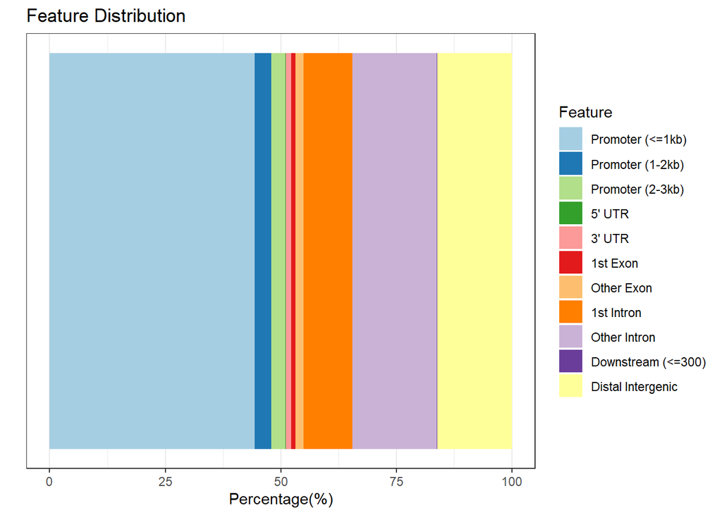

```r
plotAnnoBar(peak_anno)
```

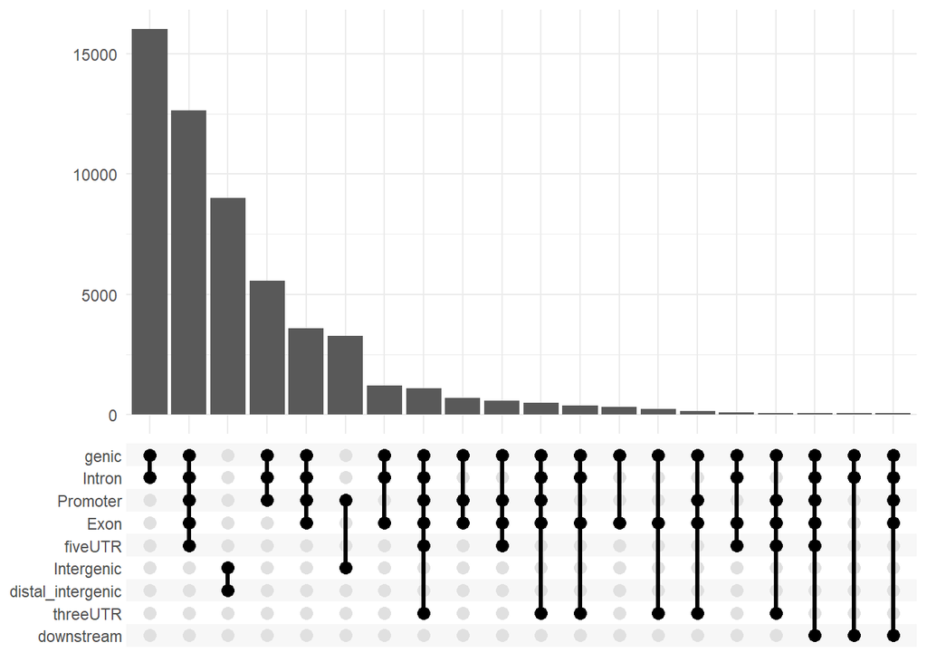

```r
upsetplot(peak_anno)
```

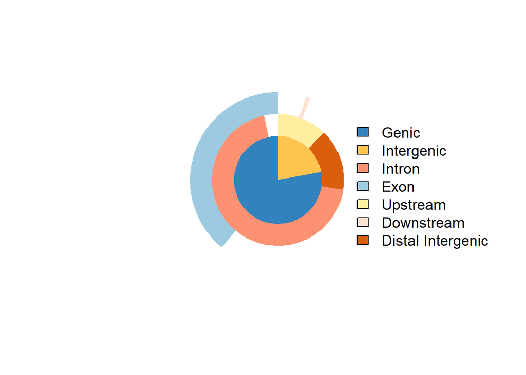

```r
vennpie(peak_anno)
```

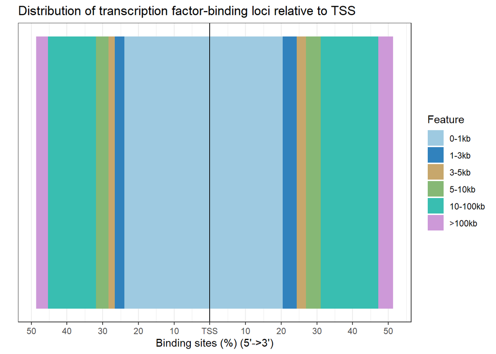

```r
plotDistToTSS(peak_anno)
```

## Enrichment analysis

```r
library(ReactomePA)
pathway_1 <- enrichPathway(as.data.frame(peak_anno)$geneId)
head(pathway_1,2)
```

```
##                          ID      Description GeneRatio   BgRatio       pvalue
## R-HSA-9012999 R-HSA-9012999 RHO GTPase cycle  409/7991 449/10899 6.061955e-22
## R-HSA-68886     R-HSA-68886          M Phase  368/7991 418/10899 5.713531e-14
##                   p.adjust       qvalue
## R-HSA-9012999 9.462712e-19 5.257949e-19
## R-HSA-68886   3.460196e-11 1.922655e-11
##                                                                                                                                                                                                                                                                                                          …
## R-HSA-9012999 57449/9341/79180/23013/128272/55160/832/998/10250/55219/9154…
## R-HSA-68886                                                                                                                                                                                                                     100526739/55920/10726/1104/5690/55143/991/11004/200014/55706…
##               Count
## R-HSA-9012999   409
## R-HSA-68886     368
```

```r
gene <- seq2gene(H3K4me3_peaks_filter, tssRegion = c(-1000, 1000), flankDistance = 3000,
                 TxDb = TxDb.Hsapiens.UCSC.hg38.knownGene)
pathway_2 <- enrichPathway(gene)
head(pathway_2, 2)
```

```
##                      ID Description GeneRatio   BgRatio       pvalue
## R-HSA-68886 R-HSA-68886     M Phase  390/8006 418/10899 3.147619e-26
## R-HSA-73894 R-HSA-73894  DNA Repair  319/8006 336/10899 1.626205e-25
##                 p.adjust       qvalue
## R-HSA-68886 4.910285e-23 2.282852e-23
## R-HSA-73894 1.268440e-22 5.897133e-23
##                                                                                                                                                                                                                                                                                                          …
## R-HSA-68886 100526739/55920/10726/1104/5690/55143/991/11004/55706/5686/6…
## R-HSA-73894                                                                                                                                                                                                                                                                                              …
##             Count
## R-HSA-68886   390
## R-HSA-73894   319
```

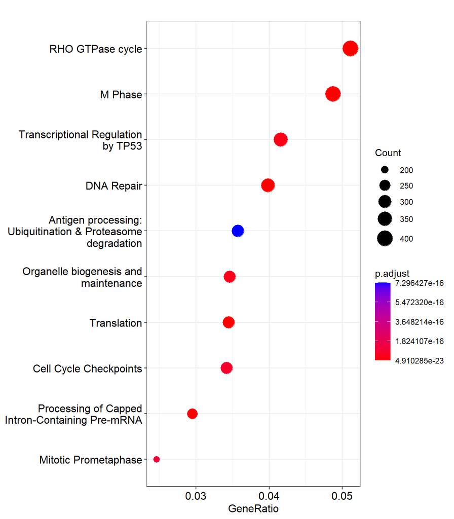

```r
dotplot(pathway_2)
```

## H3k27ac

```r
H3K27ac_peaks_filter
```

```
## GRanges object with 68610 ranges and 7 metadata columns:
##           seqnames            ranges strand |                     V4        V5
##              <Rle>         <IRanges>  <Rle> |            <character> <integer>
##       [1]     chr1     778132-778601      * |  SRR18425902_peak_1933       121
##       [2]     chr1     817129-817344      * |  SRR18425902_peak_1934        40
##       [3]     chr1     817462-818362      * |  SRR18425902_peak_1935        38
##       [4]     chr1     826957-827219      * |  SRR18425902_peak_1936        99
##       [5]     chr1   1012708-1013353      * |  SRR18425902_peak_1937        64
##       ...      ...               ...    ... .                    ...       ...
##   [68606]     chrY 24039650-24039799      * | SRR18425902_peak_70566        52
##   [68607]     chrY 25630343-25630511      * | SRR18425902_peak_70567        64
##   [68608]     chrY 25630820-25630997      * | SRR18425902_peak_70568        40
##   [68609]     chrY 25643290-25643622      * | SRR18425902_peak_70569        40
##   [68610]     chrY 25821614-25821763      * | SRR18425902_peak_70570        40
##                    V6        V7        V8        V9       V10
##           <character> <numeric> <numeric> <numeric> <integer>
##       [1]           .   8.55402  14.87400  12.11240       359
##       [2]           .   4.99772   6.24693   4.07944       146
##       [3]           .   4.86736   5.94877   3.84239       708
##       [4]           .   7.83717  12.52290   9.93966       187
##       [5]           .   6.61527   8.81448   6.46873       371
##       ...         ...       ...       ...       ...       ...
##   [68606]           .   5.71640   7.49159   5.24611        42
##   [68607]           .   6.43507   8.78682   6.44153        89
##   [68608]           .   5.23728   6.24693   4.07944        50
##   [68609]           .   5.47684   6.24693   4.07944        83
##   [68610]           .   4.99772   6.24693   4.07944        80
##   -------
##   seqinfo: 235 sequences from an unspecified genome; no seqlengths
```

```r
tag_matrix_27 <- getTagMatrix(H3K27ac_peaks_filter, windows = promoter)
```

```
## >> preparing start_site regions by gene... 2023-05-11 18:29:25
## >> preparing tag matrix...  2023-05-11 18:29:25
```

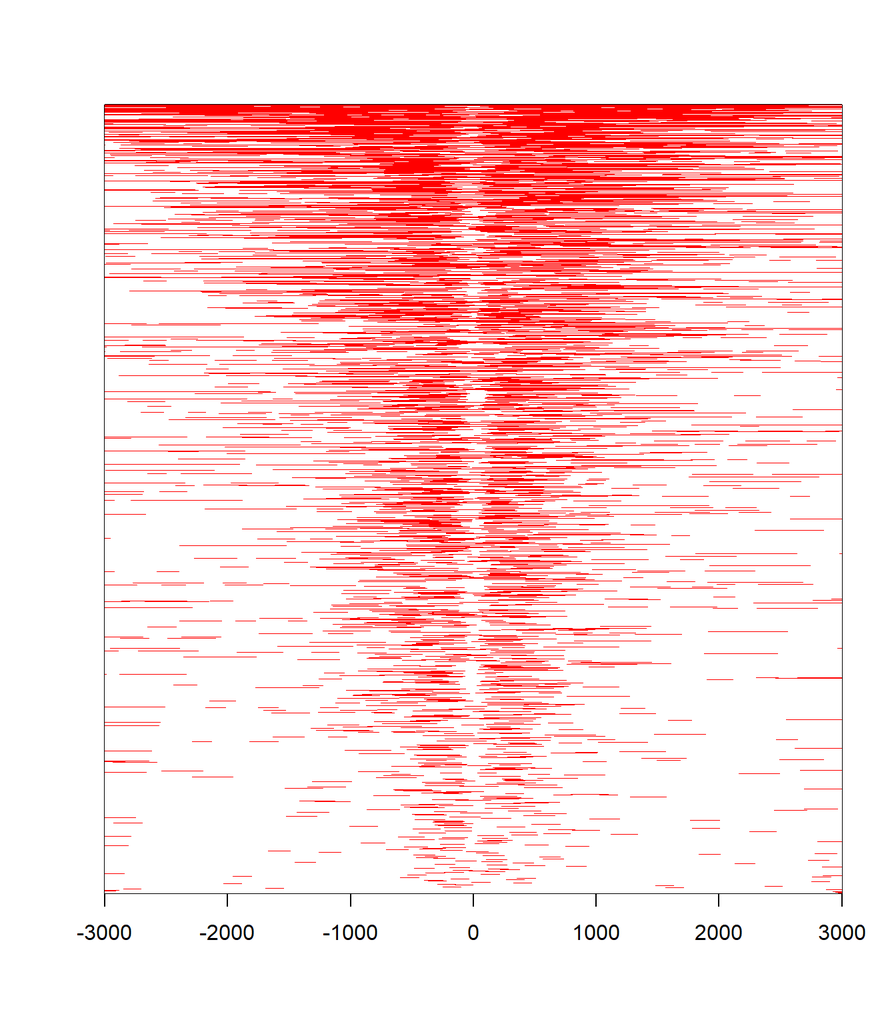

```r
tagHeatmap(tag_matrix_27, xlim = c(-3000, 3000))
```

```
## >> plotting figure...             2023-05-11 18:29:41
```

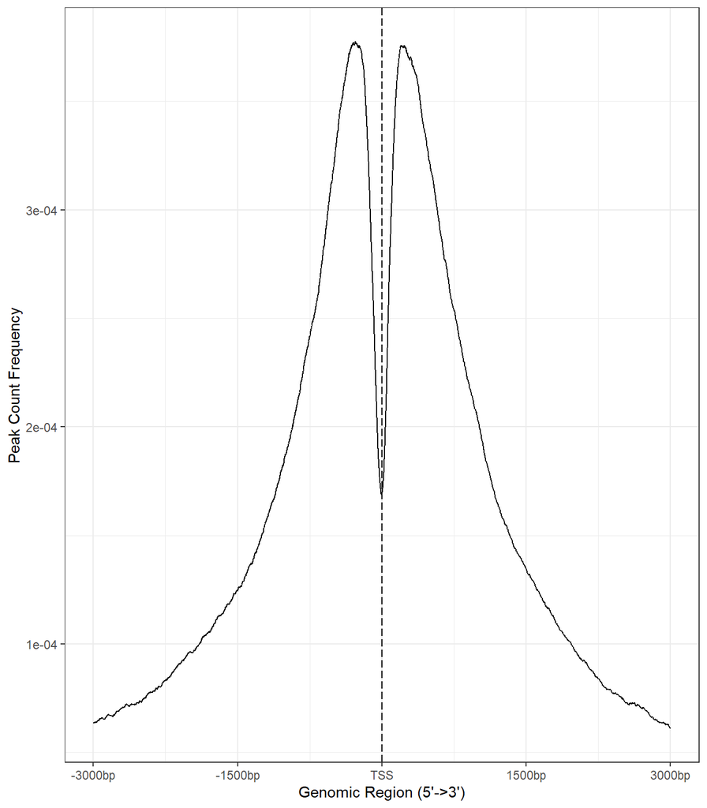

```r
plotAvgProf(tag_matrix_27, xlim = c(-3000, 3000))
```

### Peak annotation

```r
peak_anno_27 <- annotatePeak(H3K27ac_peaks_filter, tssRegion = c(-3000, 3000), TxDb = TxDb.Hsapiens.UCSC.hg38.knownGene,
                             annoDb = 'org.Hs.eg.db')
```

```
## >> preparing features information...      2023-05-11 18:29:44
## >> identifying nearest features...        2023-05-11 18:29:44
## >> calculating distance from peak to TSS...   2023-05-11 18:29:47
## >> assigning genomic annotation...        2023-05-11 18:29:47
## >> adding gene annotation...          2023-05-11 18:29:51
## >> assigning chromosome lengths           2023-05-11 18:29:51
## >> done...                    2023-05-11 18:29:51
```

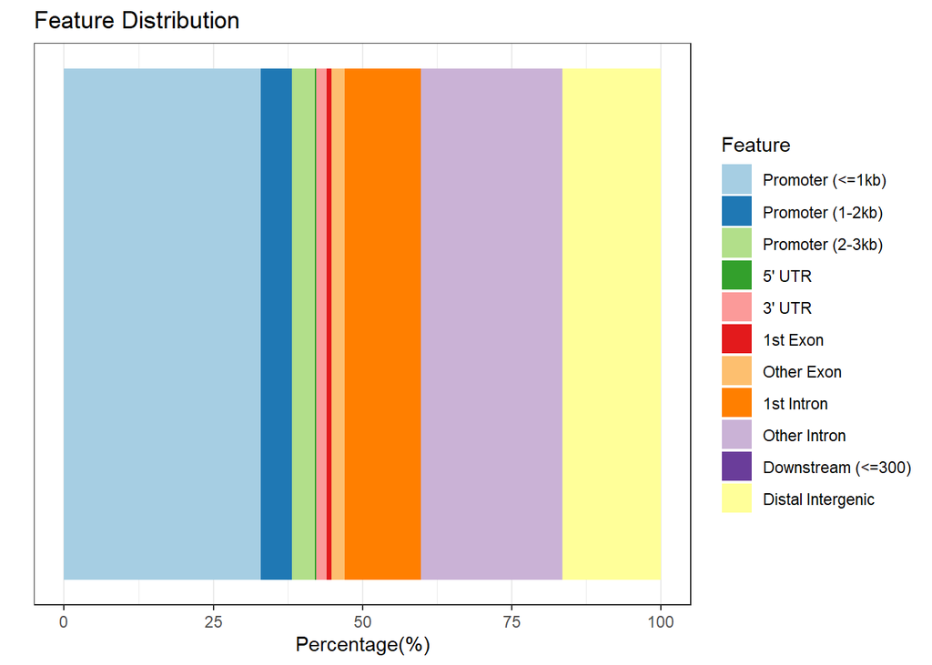

```r
plotAnnoBar(peak_anno_27)
```

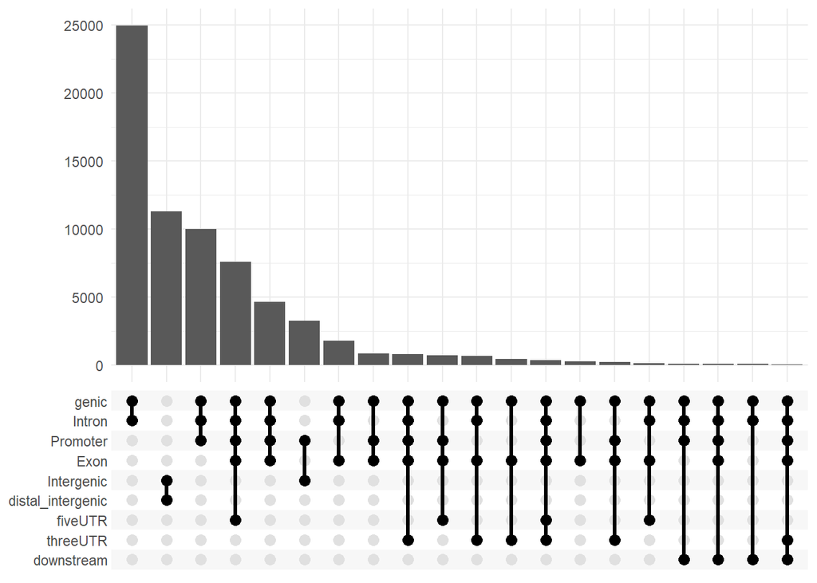

```r
upsetplot(peak_anno_27)
```

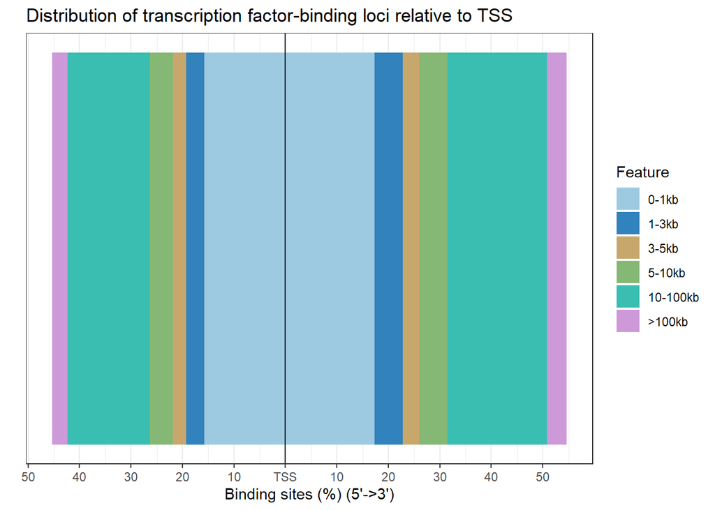

```r
plotDistToTSS(peak_anno_27)
```

### Enrichment

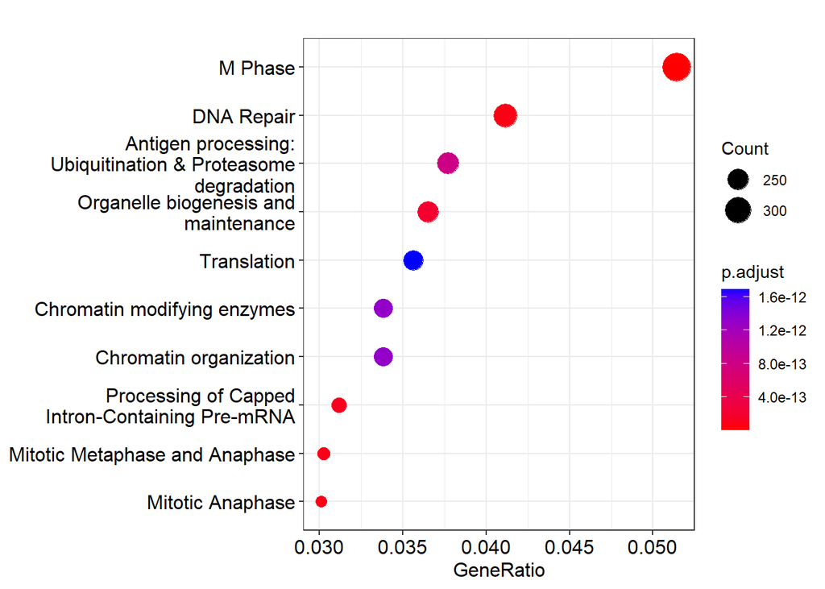

```r
pathway_3 <- enrichPathway(as.data.frame(peak_anno_27)$geneId)
dotplot(pathway_3)
```

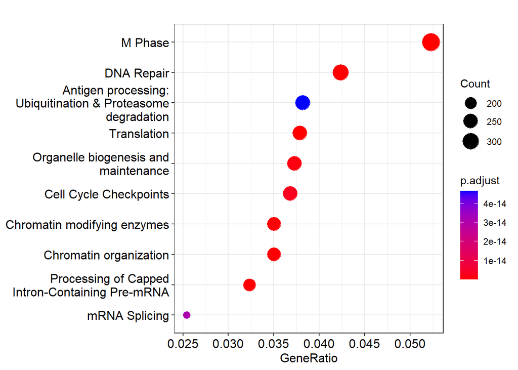

```r
gene_27 <- seq2gene(H3K27ac_peaks_filter, tssRegion = c(-1000, 1000), flankDistance = 3000,
                    TxDb = TxDb.Hsapiens.UCSC.hg38.knownGene)
pathway_4 <- enrichPathway(gene_27)
dotplot(pathway_4)
```

## Comperative analysis of both data sets

```r
files_list <- list(H3k27ac = H3K27ac_peaks_filter, H3k4me3 = H3K4me3_peaks_filter)
tag_matrix_list <- lapply(files_list, getTagMatrix, windows=promoter)
```

```
## >> preparing start_site regions by gene... 2023-05-11 18:30:28
## >> preparing tag matrix...  2023-05-11 18:30:28
## >> preparing start_site regions by gene... 2023-05-11 18:30:32
## >> preparing tag matrix...  2023-05-11 18:30:32
```

```
## >> plotting figure...             2023-05-11 18:30:38
```

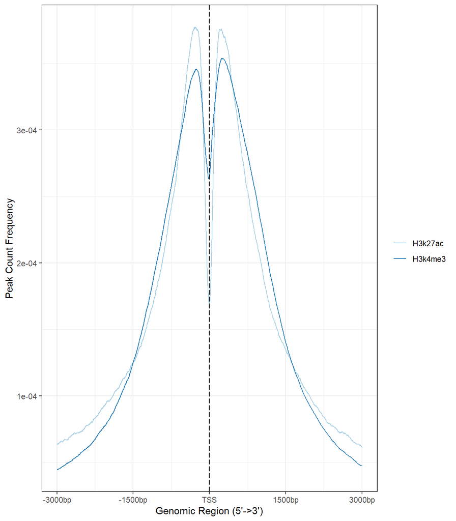

```r
plotAvgProf(tag_matrix_list, xlim = c(-3000, 3000))
```

```
## >> plotting figure...             2023-05-11 18:30:38
## >> Running bootstrapping for tag matrix...        2023-05-11 18:33:08
## >> Running bootstrapping for tag matrix...        2023-05-11 18:36:23
```

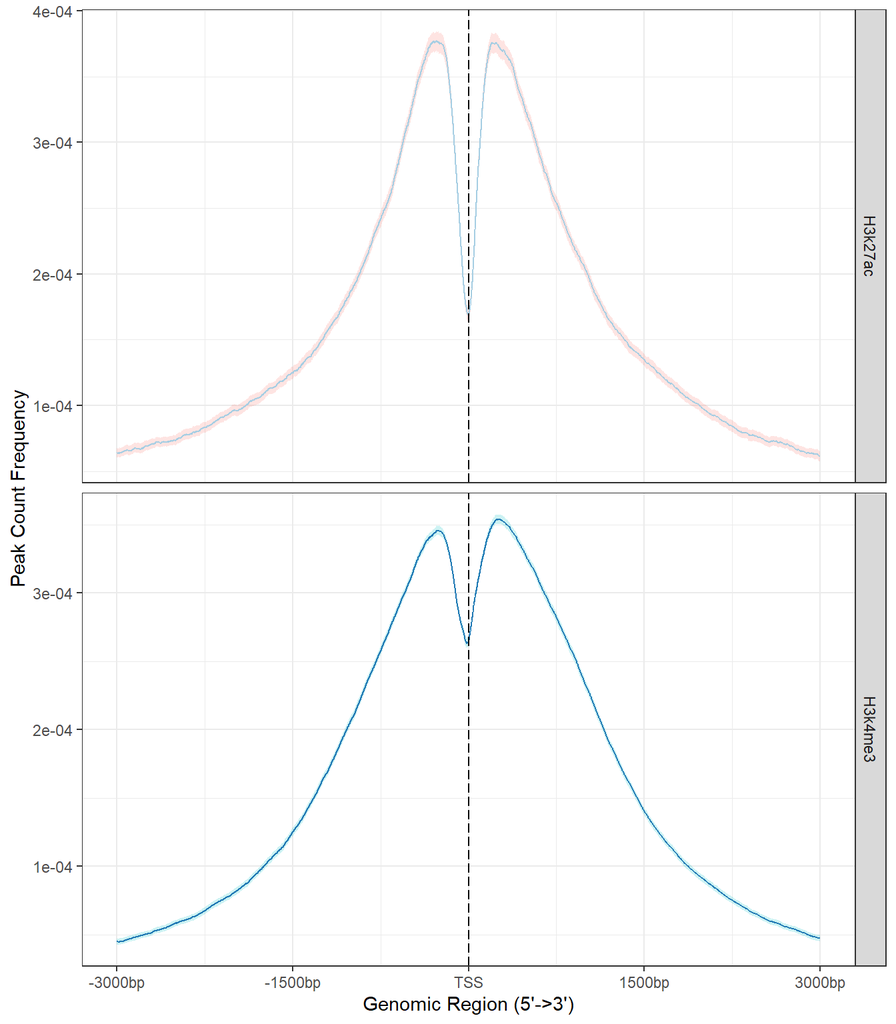

```r
plotAvgProf(tag_matrix_list, xlim = c(-3000, 3000), conf = 0.95, resample=500, facet='row')
```

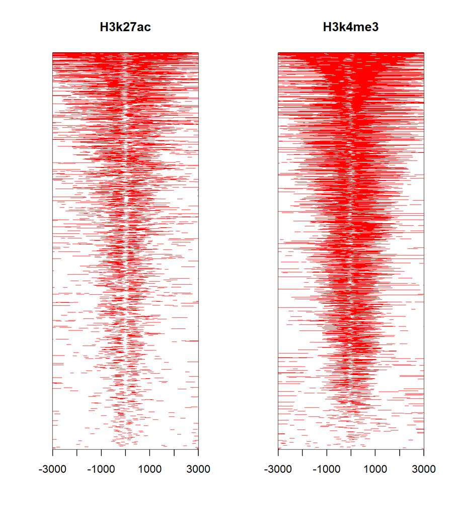

```r
tagHeatmap(tag_matrix_list, xlim = c(-3000, 3000))
```

### Peak annotation

```r
peak_anno_list <- lapply(files_list, annotatePeak, TxDb=TxDb.Hsapiens.UCSC.hg38.knownGene,
                         tssRegion=c(-3000, 3000))
```

```
## >> preparing features information...      2023-05-11 18:36:59
## >> identifying nearest features...        2023-05-11 18:36:59
## >> calculating distance from peak to TSS...   2023-05-11 18:37:01
## >> assigning genomic annotation...        2023-05-11 18:37:01
## >> assigning chromosome lengths           2023-05-11 18:37:06
## >> done...                    2023-05-11 18:37:06
## >> preparing features information...      2023-05-11 18:37:06
## >> identifying nearest features...        2023-05-11 18:37:06
## >> calculating distance from peak to TSS...   2023-05-11 18:37:07
## >> assigning genomic annotation...        2023-05-11 18:37:07
## >> assigning chromosome lengths           2023-05-11 18:37:11
## >> done...                    2023-05-11 18:37:11
```

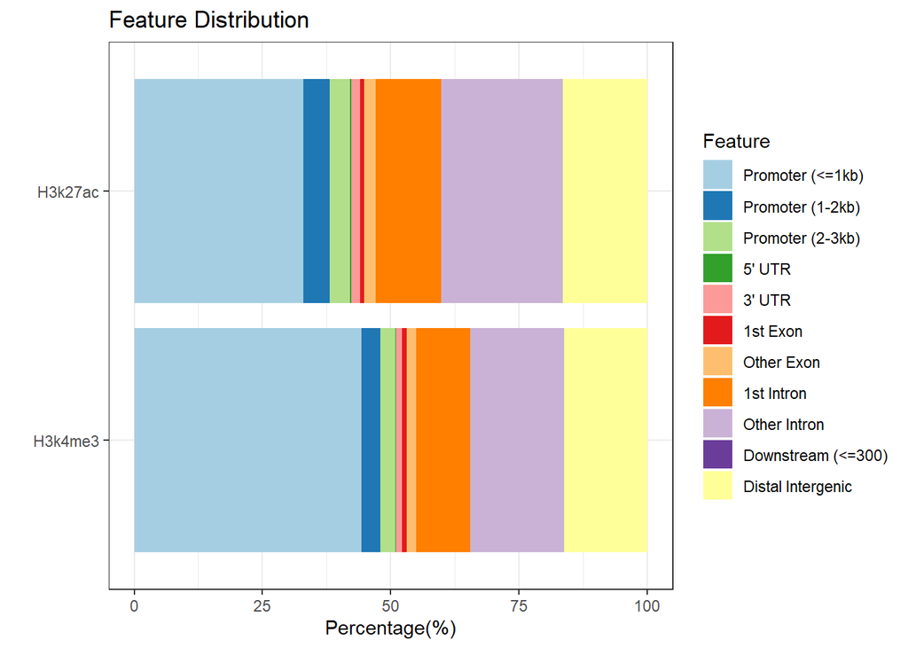

```r
plotAnnoBar(peak_anno_list)
```

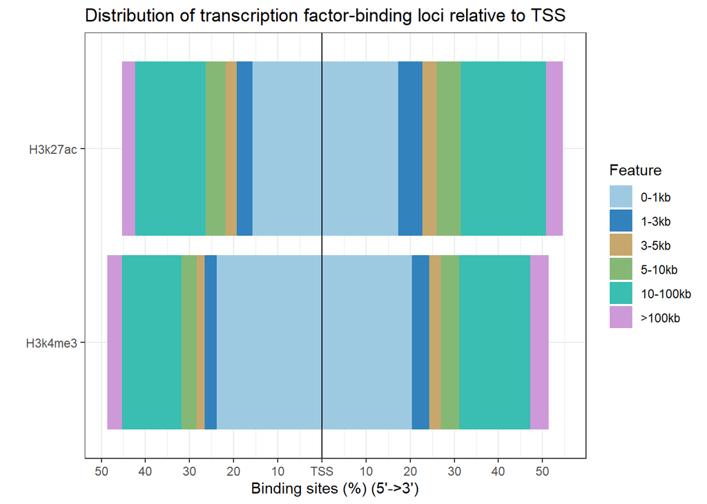

```r
plotDistToTSS(peak_anno_list)
```

### Enrichment - comparing enriched pathways

```r
genes <- lapply(peak_anno_list, function(x) { as.data.frame(x)$geneId})
names(genes)
```

```
## [1] "H3k27ac" "H3k4me3"
```

```r
compKEGG <- compareCluster(geneClusters = genes,
                           fun = 'enrichKEGG',
                           pvalueCutoff = 0.05,
                           pAdjustMethod = 'BH')
```

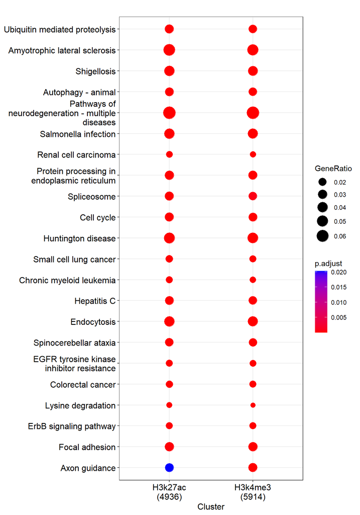

```r
dotplot(compKEGG, showCategory=15)
```

```r
universe_genes <- genes(TxDb.Hsapiens.UCSC.hg38.knownGene)
```

```
##   1662 genes were dropped because they have exons located on both strands
##   of the same reference sequence or on more than one reference sequence,
##   so cannot be represented by a single genomic range.
##   Use 'single.strand.genes.only=FALSE' to get all the genes in a
##   GRangesList object, or use suppressMessages() to suppress this message.
```

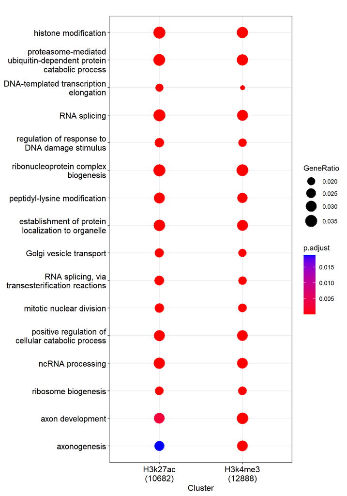

```r
compGO <- compareCluster(geneClusters = genes,
                         fun = 'enrichGO',
                         pvalueCutoff = 0.05,
                         pAdjustMethod = 'BH',
                         OrgDb = org.Hs.eg.db,
                         universe=universe_genes,
                         ont = 'BP')
dotplot(compGO, showCategory=10)
```

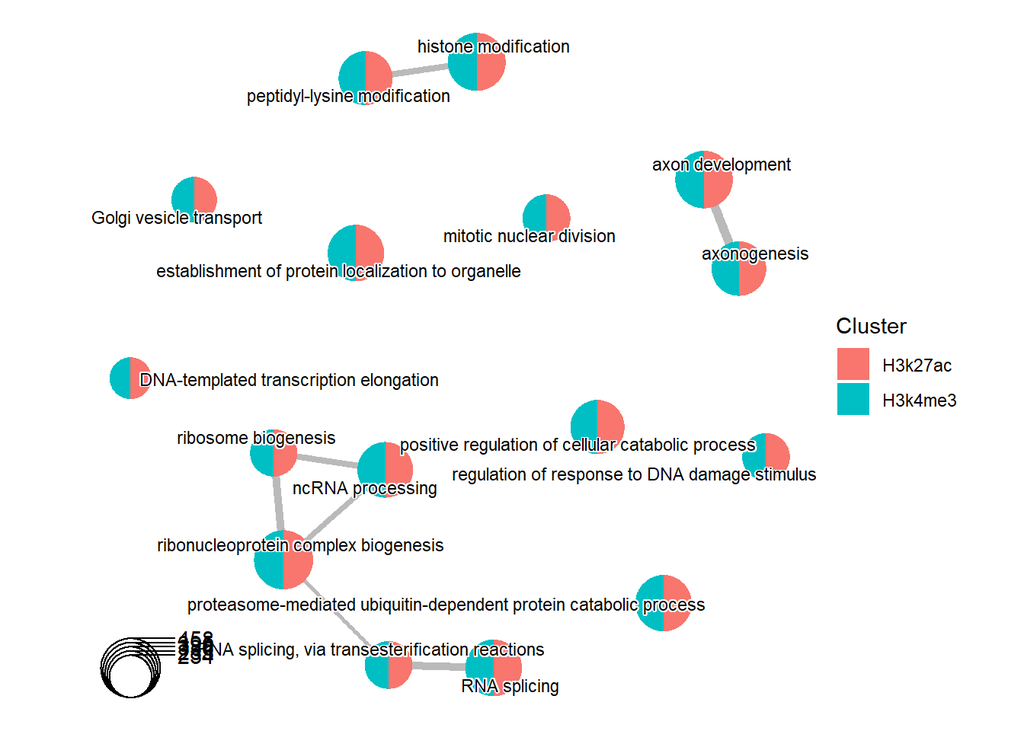

```r
library(enrichplot)
Go_results_plot <- pairwise_termsim(compGO)
emapplot(Go_results_plot, showCategory=10)
```

```r
library(msigdbr)
msig_t2g <- msigdbr(species = 'Homo sapiens', category = 'C5', subcategory = NULL)
msig_t2g <- msig_t2g %>%
  select(gs_name, entrez_gene)
msig_t2g
```

```
## # A tibble: 1,424,471 × 2
##    gs_name                                          entrez_gene
##    <chr>                                                  <int>
##  1 GOBP_10_FORMYLTETRAHYDROFOLATE_METABOLIC_PROCESS       60496
##  2 GOBP_10_FORMYLTETRAHYDROFOLATE_METABOLIC_PROCESS       10840
##  3 GOBP_10_FORMYLTETRAHYDROFOLATE_METABOLIC_PROCESS      160428
##  4 GOBP_10_FORMYLTETRAHYDROFOLATE_METABOLIC_PROCESS        4522
##  5 GOBP_10_FORMYLTETRAHYDROFOLATE_METABOLIC_PROCESS       25902
##  6 GOBP_10_FORMYLTETRAHYDROFOLATE_METABOLIC_PROCESS      441024
##  7 GOBP_2FE_2S_CLUSTER_ASSEMBLY                          552900
##  8 GOBP_2FE_2S_CLUSTER_ASSEMBLY                          654483
##  9 GOBP_2FE_2S_CLUSTER_ASSEMBLY                           10539
## 10 GOBP_2FE_2S_CLUSTER_ASSEMBLY                           51218
## # ℹ 1,424,461 more rows
```

```r
hallmark <- enricher(genes[1], universe = universe_genes, TERM2GENE = msig_t2g)
```

```
## --> No gene can be mapped....
```

```
## --> Expected input gene ID: 3417,27284,4343,2975,8460,3420
```

```
## --> return NULL...
```